# brewsTest

# 3. Assess missing data

-Special Release, The Crowler^tm, Can'd aid foundation are missing ABV/IBU/Style -The rest can be imputed based on their Style -Cedar creek - Special Release is ambiguous, missing ABV/IBU/Style and will be dropped as it does not solve the QOI. -Oskar Blues Brewery - The Crowler is not an actual beer but a type of can -Oskar Blues Brewery - Can'd aid foundation is a relief effort that sends water so it does not fit in the dataset. -Beer ID 2364, Royal Lager of Weston Brewing has no ABV/IBU -Same for BID - 2322 Fort Pitt Brewing Company Fort Pitt Ale -Oskar Blues Brewery Birth IPA, 1750 -710, no data -MillKing It Productions AXL Pale Ale, 273 - out of business no info -1095 no data -963 no data

```r
# summary(bdat_test)
# Found some NA's
# table(is.na(bdat))
#
# FALSE  TRUE
# 23033  1067

# prints only NA data
# datatable(bdat %>%
#  filter(is.na(ABV) & is.na(IBU)))

# how many data points are missing both abv and ibu
# dim(bdat %>%
#  filter(is.na(ABV) & is.na(IBU)))

# We searched by hand for ABV/IBU values when both were missing, if only one was missing we will impute.

# the following line removes these NA points
bdat_clean <- bdat %>% filter(bdat$Beer_ID!=2210 & bdat$Beer_ID!=1796 & bdat$Beer_ID!=1790 & bdat$Beer_ID!=2364&
bdat$Beer_ID!=2322& bdat$Beer_ID!=1750& bdat$Beer_ID!=710& bdat$Beer_ID!=273& bdat$Beer_ID!=1095& bdat$Beer_ID!=963)

# bdat_mice <- aggr(bdat_test, col=c('navyblue','yellow'),
#                     numbers=TRUE, sortVars=TRUE,
#                     labels=names(bdat), cex.axis=.7,
#                     gap=3, ylab=c("Missing data","Pattern"))

# very small percentage of the data is NA but we will still impute for analysis purposes
# summary(bdat$Style)

# check Style for NA
# bdat_clean %>% filter(isEmpty(Style))
```

```r
imputeMissingStyle <- function(beer_id, style){
    if(beer_id=="2527"){
    style = "Scottish-Style Amber Ale"
  }
    if(beer_id=="1635"){
    style = "Lager"
    }
  style
}

# Update ABV and IBU for NA's; to hand selected data use  %>% select(Beer_ID, Brewery, Drink_name, ABV, IBU)
bdat_hand_updated <-bdat_clean %>%
    filter(is.na(ABV) & is.na(IBU)) %>% rows_update(tibble(Beer_ID = c(2382, 2381, 1948, 1347, 2595, 1163, 940, 2490, 2489, 2488, 2487, 2472, 779, 364, 60, 59, 58, 57, 652, 2344, 2342, 1752, 61, 1724, 774, 121, 1784, 1541, 1025, 219, 307, 1096, 1056, 944, 731, 870, 869, 868, 867, 763, 504, 524, 450, 449, 448, 447, 446, 520, 506, 142, 335, 64), ABV = c(0.075, 0.055, 0.045, 0.060, 0.062, 0.0499, 0.06, 0.061, 0.038, 0.057, 0.051, 0.055, 0.05, 0.07, 0.052, 0.05, 0.049, 0.051, 0.07, 0.055, 0.049, 0.07, 0.052, 0.07, 0.058, 0.052, 0.07, 0.052, 0.086, 0.051, 0.06, 0.062, 0.055, 0.05, 0.055, 0.042, 0.05, 0.045, 0.039, 0.052, 0.072, 0.045, 0.061, 0.064, 0.058, 0.049, 0.05, 0.042, 0.05, 0.065, 0.065, 0.05), IBU = c(NA, 3.57, 65, 23, NA, 15, NA, 40, 7, 32, 35, NA, 5, NA, NA, NA, NA, NA, 80, NA, NA, NA, 28, NA, NA, 12, 40, 21, 80, NA, 38, NA, NA, 25, NA, NA, NA, NA, NA, NA, NA, NA, NA, NA, NA, NA, NA, NA, NA, NA, 70, 17)))
```

```
## Matching, by = "Beer_ID"
```

```r
#bdat_hand_updated

bdat_with_hand_updates = merge(bdat_hand_updated,bdat_clean,by="Beer_ID",all.y = TRUE) %>% rowwise %>% mutate(Brewery_id=Brewery_id.y, Drink_name=Drink_name.y, Ounces
=Ounces.y, Brewery=Brewery.y, City=City.y, State=State.y, Style = imputeMissingStyle(Beer_ID, Style.y),IBU = if_else(isEmpty(IBU.y), IBU.x, IBU.y), ABV = if_else(isEmpty(ABV.y), ABV.x, ABV.y)) %>% select(Brewery_id, ABV, IBU, Drink_name, Style, Ounces, Brewery, City, State)
#bdat_with_hand_updates

bdat_with_hand_updates %>% filter(isEmpty(Style))
```

```
## # A tibble: 0 x 9
## # Rowwise:
## # ... with 9 variables: Brewery_id <dbl>, ABV <dbl>, IBU <dbl>,
## #   Drink_name <chr>, Style <chr>, Ounces <dbl>, Brewery <chr>, City <chr>,
## #   State <chr>
```

```r
bdat_with_hand_updates %>% filter(Brewery_id=="67")
```

```
## # A tibble: 8 x 9
## # Rowwise:
##   Brewery_id   ABV   IBU Drink_name   Style      Ounces Brewery     City   State
##        <dbl> <dbl> <dbl> <chr>        <chr>       <dbl> <chr>       <chr>  <chr>
## 1         67 0.044     5 Yo Soy Un B~ Berliner ~     12 Freetail B~ San A~ TX
## 2         67 0.059    70 Soul Doubt   American ~     12 Freetail B~ San A~ TX
## 3         67 0.042    10 Rye Wit      Witbier        12 Freetail B~ San A~ TX
## 4         67 0.068    NA Original     American ~     12 Freetail B~ San A~ TX
## 5         67 0.042    20 Bat Outta H~ Munich He~     12 Freetail B~ San A~ TX
## 6         67 0.06     NA Pinata Prot~ Witbier        12 Freetail B~ San A~ TX
## 7         67 0.065    33 Texicali     American ~     12 Freetail B~ San A~ TX
## 8         67 0.053    27 OktoberFies~ Scottish-~     12 Freetail B~ San A~ TX
```

```r
# which(is.na(bdat_with_hand_updates$ABV) | is.na(bdat_with_hand_updates$IBU))

# Impute IBU
bdat.IBU.Summary <- bdat_with_hand_updates %>% filter(!isEmpty(IBU)) %>% group_by(Style) %>% summarise(median_IBU_by_style=median(IBU))
#bdat.IBU.Summary

bdat.imputed.IBU <-merge(bdat_with_hand_updates, bdat.IBU.Summary, by="Style")  %>% mutate(IBU.clean = if_else(isEmpty(IBU), median_IBU_by_style, as.double(IBU)))
#bdat.imputed.IBU

bdat.imputed.IBU.clean = bdat.imputed.IBU[,-c(4)]
#bdat.imputed.IBU.clean

bdat.imputed.IBU.clean %>% filter(isEmpty(Style))
```

```
##  [1] Style               Brewery_id          ABV
##  [4] Drink_name          Ounces              Brewery
##  [7] City                State               median_IBU_by_style
## [10] IBU.clean
## <0 rows> (or 0-length row.names)
```

```r
# Impute ABV
# bdat.ABV.Summary <- bdat.imputed.IBU %>% filter(!isEmpty(ABV)) %>% group_by(Style) %>% summarise(median_ABV_by_style=median(ABV))
# bdat.ABV.Summary

# bdat.imputed.ABV_IBU <-merge(bdat.imputed.IBU, bdat.ABV.Summary, by="Style")  %>% mutate(ABV.clean = if_else(isEmpty(ABV), median_ABV_by_style, as.double(ABV)))
# bdat.imputed.ABV_IBU

# which(is.na(bdat.imputed.ABV_IBU$ABV.clean) | is.na(bdat.imputed.ABV_IBU$IBU.clean))

bdat_mice_clean <- aggr(bdat.imputed.IBU.clean, col=c('navyblue','yellow'),
                    numbers=TRUE, sortVars=TRUE,
                    labels=names(bdat.imputed.IBU.clean), cex.axis=.7,
                    gap=3, ylab=c("Missing data","Pattern"))
```

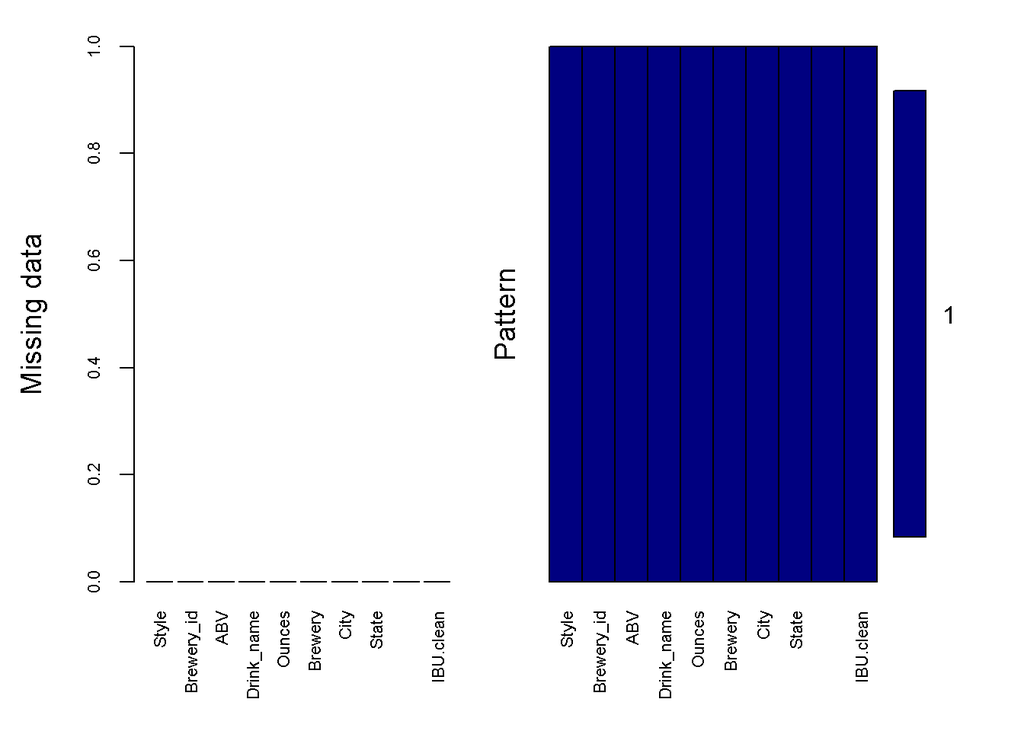

```
##
##  Variables sorted by number of missings:
##             Variable Count
##                Style     0
##           Brewery_id     0
##                  ABV     0
##           Drink_name     0
##               Ounces     0
##              Brewery     0
##                 City     0
##                State     0
##  median_IBU_by_style     0
##            IBU.clean     0
```

```r
summary(bdat.imputed.IBU.clean)
```

```
##     Style             Brewery_id       ABV           Drink_name
##  Length:2348        Min.   :  1   Min.   :0.02700   Length:2348
##  Class :character   1st Qu.: 92   1st Qu.:0.05000   Class :character
##  Mode  :character   Median :204   Median :0.05600   Mode  :character
##                     Mean   :231   Mean   :0.05967
##                     3rd Qu.:366   3rd Qu.:0.06700
##                     Max.   :558   Max.   :0.12800
##      Ounces        Brewery              City              State
##  Min.   : 8.40   Length:2348        Length:2348        Length:2348
##  1st Qu.:12.00   Class :character   Class :character   Class :character
##  Median :12.00   Mode  :character   Mode  :character   Mode  :character
##  Mean   :13.56
##  3rd Qu.:16.00
##  Max.   :32.00
##  median_IBU_by_style   IBU.clean
##  Min.   : 8.00       Min.   :  3.57
##  1st Qu.:21.00       1st Qu.: 21.00
##  Median :30.00       Median : 32.00
##  Mean   :40.03       Mean   : 40.46
##  3rd Qu.:69.00       3rd Qu.: 60.00
##  Max.   :96.00       Max.   :138.00
```

# 5. Which state has the maximum alcoholic (ABV) beer? Which state has the most bitter (IBU) beer?

```r
kable(head(arrange(bdat, desc(ABV))))
```

| Brewery_id | Drink_name | Beer_ID | ABV | IBU | Style | Ounces | Brewery | City | State |
| --- | --- | --- | --- | --- | --- | --- | --- | --- | --- |
| 52 | Lee Hill Series Vol. 5 - Belgian Style Quadrupel Ale | 2565 | 0.128 | NA | Quadrupel (Quad) | 19.2 | Upslope Brewing Company | Boulder | CO |
| 2 | London Balling | 2685 | 0.125 | 80 | English Barleywine | 16.0 | Against the Grain Brewery | Louisville | KY |
| 18 | Csar | 2621 | 0.120 | 90 | Russian Imperial Stout | 16.0 | Tin Man Brewing Company | Evansville | IN |
| 52 | Lee Hill Series Vol. 4 - Manhattan Style Rye Ale | 2564 | 0.104 | NA | Rye Beer | 19.2 | Upslope Brewing Company | Boulder | CO |
| 47 | 4Beans | 2574 | 0.100 | 52 | Baltic Porter | 12.0 | Sixpoint Craft Ales | Brooklyn | NY |
| 11 | Wizard Burial Ground | 2137 | 0.099 | NA | Quadrupel (Quad) | 16.0 | Brewery Vivant | Grand Rapids | MI |

```r
kable(head(arrange(bdat, desc(IBU))))
```

| Brewery_id | Drink_name | Beer_ID | ABV | IBU | Style | Ounces | Brewery | City | State |
| --- | --- | --- | --- | --- | --- | --- | --- | --- | --- |
| 375 | Bitter Bitch Imperial IPA | 980 | 0.082 | 138 | American Double / Imperial IPA | 12 | Astoria Brewing Company | Astoria | OR |
| 345 | Troopers Alley IPA | 1676 | 0.059 | 135 | American IPA | 12 | Wolf Hills Brewing Company | Abingdon | VA |
| 231 | Dead-Eye DIPA | 2067 | 0.090 | 130 | American Double / Imperial IPA | 16 | Cape Ann Brewing Company | Gloucester | MA |
| 100 | Bay of Bengal Double IPA (2014) | 2440 | 0.089 | 126 | American Double / Imperial IPA | 12 | Christian Moerlein Brewing Company | Cincinnati | OH |
| 62 | Abrasive Ale | 15 | 0.097 | 120 | American Double / Imperial IPA | 16 | Surly Brewing Company | Brooklyn Center | MN |
| 273 | Heady Topper | 1111 | 0.080 | 120 | American Double / Imperial IPA | 16 | The Alchemist | Waterbury | VT |